# Reproducible Research: Peer assessment 1

### *04 June 2017*

# ### Github repository with RMarkdown source code: https://github.com/maksymkulish/RepData_PeerAssessment1

## Introduction

Introduction

It is now possible to collect a large amount of data about personal movement using activity monitoring devices such as a Fitbit, Nike Fuelband, or Jawbone Up. These type of devices are part of the “quantified self” movement – a group of enthusiasts who take measurements about themselves regularly to improve their health, to find patterns in their behavior, or because they are tech geeks. But these data remain under-utilized both because the raw data are hard to obtain and there is a lack of statistical methods and software for processing and interpreting the data.

This assignment makes use of data from a personal activity monitoring device. This device collects data at 5 minute intervals through out the day. The data consists of two months of data from an anonymous individual collected during the months of October and November, 2012 and include the number of steps taken in 5 minute intervals each day.

The data for this assignment can be downloaded from the course web site:

Dataset: Activity monitoring data [52K] The variables included in this dataset are:

steps: Number of steps taking in a 5-minute interval (missing values are coded as NA) date: The date on which the measurement was taken in YYYY-MM-DD format interval: Identifier for the 5-minute interval in which measurement was taken The dataset is stored in a comma-separated-value (CSV) file and there are a total of 17,568 observations in this dataset.

This document presents the results of the Reproducible Research’s Peer Assessment 1 in a report using **a single R markdown document** that can be processed by **knitr** and be transformed into an HTML file.

Through this report you can see that activities on weekdays mostly follow a work related routine, where we find some more intensity activity in little a free time that the employ can made some sport.

## Prepare the R environment

Throughout this report when writing code chunks in the R markdown document, **always use echo = TRUE** so that someone else will be able to read the code.

# Reproducible Research: Peer Assessment 1

## Loading and preprocessing the data

##### 1. Load the data (i.e. read.csv())

```r
if(!file.exists('activity.csv')){
    unzip('activity.zip')
}
activitySet <- read.csv('activity.csv')
```

##### 2. Process/transform the data (if necessary) into a format suitable for your analysis

```r
#activitySet$interval <- strptime(gsub("([0-9]{1,2})([0-9]{2})", "\\1:\\2", activitySet$interval), format='%H:%M')
```

## What is mean total number of steps taken per day?

```r
stepsByDay <- tapply(activitySet$steps, activitySet$date, sum, na.rm=TRUE)
```

##### 1. Make a histogram of the total number of steps taken each day

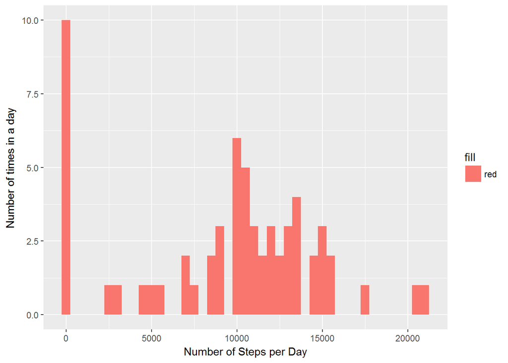

```r
qplot(stepsByDay, fill='red', xlab='Number of Steps per Day', ylab='Number of times in a day', binwidth=500)
```

##### 2. Calculate and report the mean and median total number of steps taken per day

```r
stepsByDayMean <- mean(stepsByDay)
stepsByDayMedian <- median(stepsByDay)
```

- Mean: 9354.2295082
- Median: 10395

## What is the average daily activity pattern?

```r
averageStepsPerTimeBlock <- aggregate(x=list(meanSteps=activitySet$steps), by=list(interval=activitySet$interval), FUN=mean, na.rm=TRUE)
```

##### 1. Make a time series plot

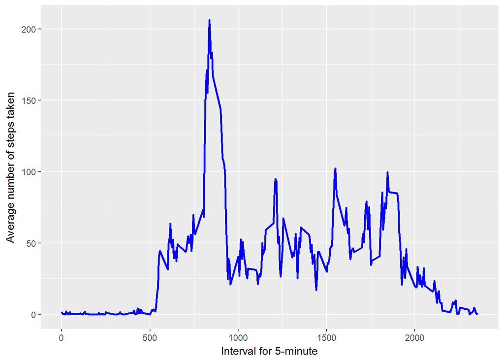

```r
ggplot(data=averageStepsPerTimeBlock, aes(x=interval, y=meanSteps)) +
    geom_line(color="blue", size=1) +
    xlab("Interval for 5-minute") +
    ylab("Average number of steps taken")
```

##### 2. Which 5-minute interval, on average across all the days in the dataset, contains the maximum number of steps?

```r
mostSteps <- which.max(averageStepsPerTimeBlock$meanSteps)
timeMostSteps <-  gsub("([0-9]{1,2})([0-9]{2})", "\\1:\\2", averageStepsPerTimeBlock[mostSteps,'interval'])
```

- Most Steps at: 8:35

## Imputing missing values

##### 1. Calculate and report the total number of missing values in the dataset

```r
numMissingValues <- length(which(is.na(activitySet$steps)))
```

- Number of missing values: 2304

##### 2. Devise a strategy for filling in all of the missing values in the dataset.

##### 3. Create a new dataset that is equal to the original dataset but with the missing data filled in.

```r
activitySetImputed <- activitySet
activitySetImputed$steps <- impute(activitySet$steps, fun=mean)
```

##### 4. Make a histogram of the total number of steps taken each day

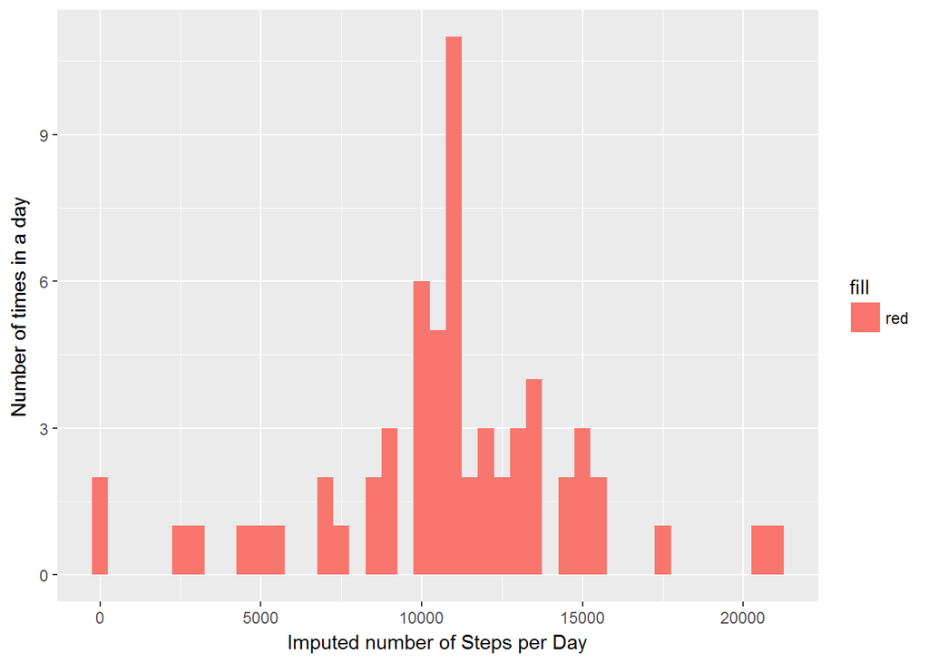

```r
stepsByDayImputed <- tapply(activitySetImputed$steps, activitySetImputed$date, sum)
qplot(stepsByDayImputed, fill='red', xlab='Imputed number of Steps per Day', ylab='Number of times in a day', binwidth=500)
```

```r
stepsByDayMeanImputed <- mean(stepsByDayImputed)
stepsByDayMedianImputed <- median(stepsByDayImputed)
```

## Are there differences in activity patterns between weekdays and weekends?

##### 1. Create a new factor variable in the dataset with two levels – “weekday” and “weekend” indicating whether a given date is a weekday or weekend day.

```r
activitySetImputed$dateType <-  ifelse(as.POSIXlt(activitySetImputed$date)$wday %in% c(0,6), 'weekend', 'weekday')
```

##### 2. Make a panel plot containing a time series plot

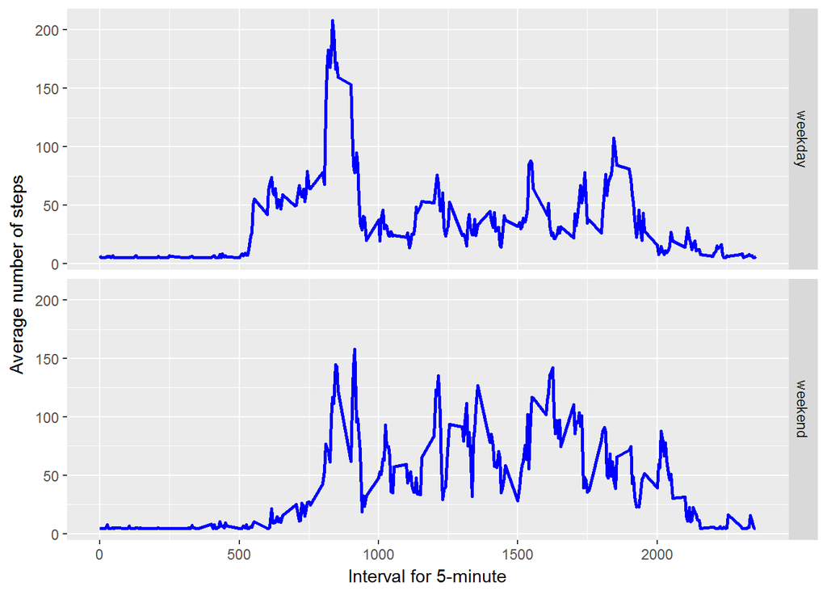

```r
averagedactivitySetImputed <- aggregate(steps ~ interval + dateType, data=activitySetImputed, mean)
ggplot(averagedactivitySetImputed, aes(interval, steps)) +
    geom_line(color="blue", size=1) +
    facet_grid(dateType ~ .) +
    xlab("Interval for 5-minute") +
    ylab("Average number of steps")
```